# The Specifics of Medical Data Analysis. HW1

Maria Bochkareva

2023-11-11

Загрузка библиотек

```r
library(readxl)
library(pROC)
library(dplyr)
library(ggplot2)
library(tidyr)
library(purrr)
```

Загрузка датасета

```r
trauma_data <- read_excel("trauma.xlsx") # Чтение файла Excel

head(trauma_data) # Просмотр первых строк данных
```

```
## # A tibble: 6 × 13
##   ...1     id Name       Sex     Age Height Weight   SBP   DBP  FOUR   GSC    Hb
##   <chr> <dbl> <chr>      <chr> <dbl> <chr>   <dbl> <dbl> <dbl> <dbl> <dbl> <dbl>
## 1 1         1 Jecelle O… Fema…    24 "68\""   176    102    78    10     8  11.4
## 2 2         2 Halie Mcc… Fema…    35 "69.8…   184.   116    86     9     7  12.2
## 3 3         3 Kole Cook  Male     39 "72.8…   210.   122   102    12    12  15
## 4 4         4 Patricia … Fema…    20 "70.5…   195.   120   100    11     9  12.2
## 5 5         5 Grace Cre… Fema…    63 "66.8…   169    112    84     9     7  12.4
## 6 6         6 Joseph Be… Male     60 "72.4…   202.   118    88    13    11  15
## # ℹ 1 more variable: Death <dbl>
```

Вывод описательных статистик для всех переменных

```r
summary(trauma_data)
```

```
##      ...1                 id             Name               Sex
##  Length:1024        Min.   :   1.0   Length:1024        Length:1024
##  Class :character   1st Qu.: 256.8   Class :character   Class :character
##  Mode  :character   Median : 512.5   Mode  :character   Mode  :character
##                     Mean   : 512.5
##                     3rd Qu.: 768.2
##                     Max.   :1024.0
##       Age           Height              Weight           SBP
##  Min.   :18.00   Length:1024        Min.   :133.3   Min.   : 90.0
##  1st Qu.:29.00   Class :character   1st Qu.:181.7   1st Qu.:106.0
##  Median :41.00   Mode  :character   Median :193.9   Median :110.0
##  Mean   :40.94                      Mean   :193.5   Mean   :110.8
##  3rd Qu.:53.00                      3rd Qu.:205.4   3rd Qu.:116.0
##  Max.   :64.00                      Max.   :253.1   Max.   :134.0
##       DBP              FOUR             GSC               Hb
##  Min.   : 58.00   Min.   : 0.000   Min.   : 3.000   Min.   : 0.0
##  1st Qu.: 78.00   1st Qu.: 7.000   1st Qu.: 6.000   1st Qu.:12.0
##  Median : 84.00   Median : 9.000   Median : 8.000   Median :13.1
##  Mean   : 84.78   Mean   : 8.853   Mean   : 7.785   Mean   :12.8
##  3rd Qu.: 90.00   3rd Qu.:11.000   3rd Qu.:10.000   3rd Qu.:14.0
##  Max.   :110.00   Max.   :16.000   Max.   :14.000   Max.   :16.2
##      Death
##  Min.   :0.0000
##  1st Qu.:0.0000
##  Median :0.0000
##  Mean   :0.3994
##  3rd Qu.:1.0000
##  Max.   :1.0000
```

Скорректируем переменные:

```r
# Преобразование id, Death и Sex в факторные переменные
trauma_data$id <- as.factor(trauma_data$id)
trauma_data$Death <- as.factor(trauma_data$Death)
trauma_data$Sex <- as.factor(trauma_data$Sex)

# Удаление символа дюймов (") и преобразование в числовой формат
trauma_data$Height <- as.numeric(gsub("\"", "", trauma_data$Height))

# Перевод из дюймов в сантиметры
trauma_data$Height <- trauma_data$Height * 0.0254

# Проверка изменений
trauma_data %>% summary()
```

```
##      ...1                 id           Name               Sex
##  Length:1024        1      :   1   Length:1024        Female:384
##  Class :character   2      :   1   Class :character   Male  :640
##  Mode  :character   3      :   1   Mode  :character
##                     4      :   1
##                     5      :   1
##                     6      :   1
##                     (Other):1018
##       Age            Height          Weight           SBP
##  Min.   :18.00   Min.   :1.621   Min.   :133.3   Min.   : 90.0
##  1st Qu.:29.00   1st Qu.:1.770   1st Qu.:181.7   1st Qu.:106.0
##  Median :41.00   Median :1.849   Median :193.9   Median :110.0
##  Mean   :40.94   Mean   :1.840   Mean   :193.5   Mean   :110.8
##  3rd Qu.:53.00   3rd Qu.:1.908   3rd Qu.:205.4   3rd Qu.:116.0
##  Max.   :64.00   Max.   :2.029   Max.   :253.1   Max.   :134.0
##
##       DBP              FOUR             GSC               Hb       Death
##  Min.   : 58.00   Min.   : 0.000   Min.   : 3.000   Min.   : 0.0   0:615
##  1st Qu.: 78.00   1st Qu.: 7.000   1st Qu.: 6.000   1st Qu.:12.0   1:409
##  Median : 84.00   Median : 9.000   Median : 8.000   Median :13.1
##  Mean   : 84.78   Mean   : 8.853   Mean   : 7.785   Mean   :12.8
##  3rd Qu.: 90.00   3rd Qu.:11.000   3rd Qu.:10.000   3rd Qu.:14.0
##  Max.   :110.00   Max.   :16.000   Max.   :14.000   Max.   :16.2
##
```

```r
# Перевод массы тела из фунтов в килограммы
trauma_data$Weight <- trauma_data$Weight * 0.453592

# Проверка результатов
summary(trauma_data$Weight)
```

```
##    Min. 1st Qu.  Median    Mean 3rd Qu.    Max.
##   60.46   82.41   87.95   87.78   93.18  114.80
```

Уберем пропущенные значения из данных, записанные как “0”.

Они присутствуют в столбце FOUR, но это возможное значение, исходя из мед данных - это кома III. В данных Hb заменяем нули на NA т.к. нет промежуточных значений в диапазоне от 0 до 9.4, и исходя из этого, вероятно, это невозможное значение гемоглобина = пропущенные данные.

```r
# Создание копии датафрейма
trauma_data_cleaned <- trauma_data

# Замена нулевых значений Hb на NA в копии
trauma_data_cleaned$Hb <- ifelse(trauma_data_cleaned$Hb == 0, NA, trauma_data_cleaned$Hb)

# Проверка результатов в новом датафрейме
summary(trauma_data_cleaned$Hb)
```

```
##    Min. 1st Qu.  Median    Mean 3rd Qu.    Max.    NA's
##    9.40   12.10   13.10   13.01   14.00   16.20      16
```

##*1. Дайте описательную статистику для переменных, включённых в датасет. Дополнительно рассчитайте, у какого количества пациентов и в каком проценте случаев у пациентов был снижен уровень гемоглобина? Используйте следующие референтные значения (Мужчины: 13.5–16 г/дл, Женщины: 12–14 г/дл).*

#Описательные статистики почищенных данных:

```r
summary(trauma_data_cleaned)
```

```
##      ...1                 id           Name               Sex
##  Length:1024        1      :   1   Length:1024        Female:384
##  Class :character   2      :   1   Class :character   Male  :640
##  Mode  :character   3      :   1   Mode  :character
##                     4      :   1
##                     5      :   1
##                     6      :   1
##                     (Other):1018
##       Age            Height          Weight            SBP
##  Min.   :18.00   Min.   :1.621   Min.   : 60.46   Min.   : 90.0
##  1st Qu.:29.00   1st Qu.:1.770   1st Qu.: 82.41   1st Qu.:106.0
##  Median :41.00   Median :1.849   Median : 87.95   Median :110.0
##  Mean   :40.94   Mean   :1.840   Mean   : 87.78   Mean   :110.8
##  3rd Qu.:53.00   3rd Qu.:1.908   3rd Qu.: 93.18   3rd Qu.:116.0
##  Max.   :64.00   Max.   :2.029   Max.   :114.80   Max.   :134.0
##
##       DBP              FOUR             GSC               Hb        Death
##  Min.   : 58.00   Min.   : 0.000   Min.   : 3.000   Min.   : 9.40   0:615
##  1st Qu.: 78.00   1st Qu.: 7.000   1st Qu.: 6.000   1st Qu.:12.10   1:409
##  Median : 84.00   Median : 9.000   Median : 8.000   Median :13.10
##  Mean   : 84.78   Mean   : 8.853   Mean   : 7.785   Mean   :13.01
##  3rd Qu.: 90.00   3rd Qu.:11.000   3rd Qu.:10.000   3rd Qu.:14.00
##  Max.   :110.00   Max.   :16.000   Max.   :14.000   Max.   :16.20
##                                                     NA's   :16
```

#Рассчеты по уровню гемоглобина:

```r
# Определение количества пациентов с сниженным уровнем гемоглобина
low_hb_men <- sum(trauma_data_cleaned$Sex == "Male" & trauma_data_cleaned$Hb < 13.5, na.rm = TRUE)
low_hb_women <- sum(trauma_data_cleaned$Sex == "Female" & trauma_data_cleaned$Hb < 12, na.rm = TRUE)
total_low_hb <- low_hb_men + low_hb_women

# Расчет процента пациентов с сниженным уровнем гемоглобина
percent_low_hb <- round((total_low_hb / nrow(trauma_data_cleaned)) * 100, 1)

# Вывод результатов
cat("Количество пациентов с сниженным уровнем гемоглобина:", total_low_hb, "\n")
```

```
## Количество пациентов с сниженным уровнем гемоглобина: 458
```

```r
cat("Процент пациентов с сниженным уровнем гемоглобина:", percent_low_hb, "%\n")
```

```
## Процент пациентов с сниженным уровнем гемоглобина: 44.7 %
```

*Количество пациентов с сниженным уровнем гемоглобина: 458*

*Процент пациентов с сниженным уровнем гемоглобина: 44.7 %*

##*2. Рассчитайте индекс массы тела у пациентов (кг/м2). Каков был средний (M (SD)) уровень ИМТ у пациентов, включённых в исследование? Какая доля пациентов имела ожирение (ИМТ > 30)?*

#Расчет ИМТ

```r
# Расчет ИМТ
trauma_data_cleaned$BMI <- trauma_data_cleaned$Weight / (trauma_data_cleaned$Height^2)

# Проверка результатов
head(trauma_data_cleaned$BMI)
```

```
## [1] 26.76041 26.53804 27.87156 27.64040 26.62758 27.04029
```

#Средний уровень ИМТ и его стандартное отклонение (SD):

```r
mean_BMI <- mean(trauma_data_cleaned$BMI, na.rm = TRUE)
sd_BMI <- sd(trauma_data_cleaned$BMI, na.rm = TRUE)

# Вывод среднего ИМТ и SD
cat("Средний ИМТ:", mean_BMI, "\n")
```

```
## Средний ИМТ: 26.00361
```

```r
cat("Стандартное отклонение ИМТ:", sd_BMI, "\n")
```

```
## Стандартное отклонение ИМТ: 2.566121
```

*Средний ИМТ: 26.00361*

*Стандартное отклонение ИМТ: 2.566121*

#Ожирение определяется как ИМТ больше 30. Рассчитаем долю таких пациентов:

```r
obesity_count <- sum(trauma_data_cleaned$BMI > 30, na.rm = TRUE)
obesity_percentage <- round((obesity_count / nrow(trauma_data_cleaned)) * 100, 1)

# Вывод доли пациентов с ожирением
cat("Доля пациентов с ожирением:", obesity_percentage, "%\n")
```

```
## Доля пациентов с ожирением: 6.7 %
```

*Доля пациентов с ожирением: 6.7 %*

##*3. Как выглядит ROC-кривая для предсказания летального исхода в течение 24 часов по переменной, характеризующей уровень гемоглобина? Постройте график. Чем может быть обусловлена такая форма кривой?*

Посчитаем площадь под кривой AUC:

```r
roc_Hb <- roc(trauma_data_cleaned$Death, trauma_data_cleaned$Hb, na.rm = TRUE, ci = T)
```

```r
cat("AUC (Area Under Curve):", auc(roc_Hb), "\n")
```

```
## AUC (Area Under Curve): 0.7077702
```

*Площадь под кривой AUC: 0.7077702*

Построим ROC-кривую:

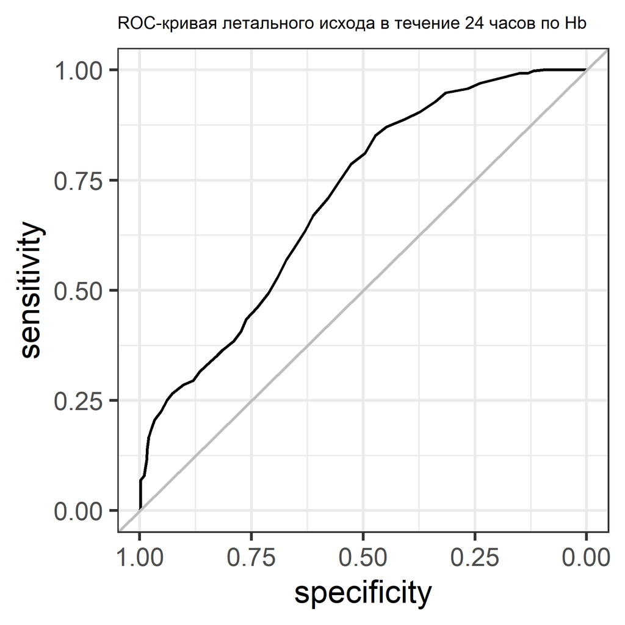

```r
roc_Hb %>%
    ggroc() +
  geom_abline(slope = 1, intercept = 1, color = "grey") +
  theme_bw() +
    ggtitle("ROC-кривая летального исхода в течение 24 часов по Hb") +
  theme_bw() +
  theme(plot.title = element_text(size = 6))
```

Форма и расположение ROC-кривой над линией случайности говорит о том, что уровень гемоглобина имеет прогностическую ценность, однако довольно низкую. AUC = 0.71 подтверждает данное предположение, основанное на визуальной оценке графика.

Такая форма кривой может быть обусловлена несколькими факторами:

Специфичность и чувствительность переменной: уровень гемоглобина, возможно, сам по себе не является идеальным предиктором летальности, но в комбинации с другими факторами может улучшить способность модели предсказывать риск.

Выборка данных: в выборке могут быть неравномерные распределения летальных исходов, что влияет на форму ROC-кривой.

##*4. Чему равна площадь под ROC-кривой, которую вы построили в вопросе 3? Чему равен 95% двусторонний ДИ для площади под ROC-кривой, которую вы построили в вопросе 3?*

```r
auc_value <- auc(roc_Hb)
auc_confidence <- ci(roc_Hb, conf.level = 0.95)

# Вывод AUC и 95% доверительного интервала
cat("AUC (Площадь под кривой):", auc_value, "\n")
```

```
## AUC (Площадь под кривой): 0.7077702
```

```r
cat("95% ДИ для AUC: [",
    round(auc_confidence[1], 3),
    "-",
    round(auc_confidence[3], 3),
    "]\n")
```

```
## 95% ДИ для AUC: [ 0.676 - 0.739 ]
```

*AUC (Площадь под кривой): 0.7077702*

*95% ДИ для AUC: [ 0.676 - 0.739 ]*

##*5. Проведите ROC-анализ и определите, какое пороговое значение является оптимальным для предсказания летального исхода в течение 24 часов по шкале комы Глазго. Какой чувствительностью и специфичностью обладает данный порог?*

Вычисление ROC-кривой для шкалы комы Глазго

```r
roc_gcs <- roc(trauma_data_cleaned$Death, trauma_data_cleaned$GSC, na.rm = TRUE)
```

[figure not shown]

```r
roc_gcs %>%
    ggroc() +
  geom_abline(slope = 1, intercept = 1, color = "grey") +
  theme_bw() +
    ggtitle("ROC Curve for Hemoglobin Level Predicting 24-hour Mortality") +
  theme_bw() +
  theme(plot.title = element_text(size = 6))
```

```r
# Нахождение оптимального порогового значения
coords_gcs <- coords(roc_gcs, "best", ret="threshold")

# Добавление чувствительности и специфичности для оптимального порога
optimal_coords <- coords(roc_gcs, "best", ret=c("sensitivity", "specificity"))

# Вывод оптимального порога, чувствительности и специфичности
cat("Оптимальное пороговое значение шкалы комы Глазго для предсказания летального исхода:", coords_gcs[1, "threshold"], "\n")
```

```
## Оптимальное пороговое значение шкалы комы Глазго для предсказания летального исхода: 7.5
```

```r
cat("Чувствительность при этом пороге:", optimal_coords[1, "sensitivity"], "\n")
```

```
## Чувствительность при этом пороге: 0.8557457
```

```r
cat("Специфичность при этом пороге:", optimal_coords[1, "specificity"], "\n")
```

```
## Специфичность при этом пороге: 0.8081301
```

*Оптимальное пороговое значение шкалы комы Глазго для предсказания летального исхода: 7.5*

*Чувствительность при этом пороге: 0.8557457*

*Специфичность при этом пороге: 0.8081301*

##*6. Какая из количественных переменных в датасете (включая рассчитанный вами ранее ИМТ) обладает наибольшей площадью под ROC-кривой? Как вы можете интерпретировать это знание? Какая количественная переменная имеет наименьшую площадь?*

```r
#Чтобы проверить Setting levels и Setting direction необходимо изменить F на T в message. Для наглядности убираем их из отчета

result <- trauma_data_cleaned %>%
  select(Death, Age, Height, Weight, SBP, DBP, FOUR, GSC, Hb, BMI) %>%
  pivot_longer(cols = -Death, names_to = "variable", values_to = "value") %>%
  group_by(variable) %>%
  summarise(
    ROC = list(roc(Death, value, ci = TRUE)),
    AUC = map_dbl(ROC, ~ auc(.x)),
    AUC_LCL = map_dbl(ROC, ~ .x$ci[1]),
    AUC_UCL = map_dbl(ROC, ~ .x$ci[3])
  ) %>%
  select(variable, AUC, AUC_LCL, AUC_UCL) %>%
  arrange(desc(AUC))

print(result)
```

```
## # A tibble: 9 × 4
##   variable   AUC AUC_LCL AUC_UCL
##   <chr>    <dbl>   <dbl>   <dbl>
## 1 FOUR     0.934   0.920   0.948
## 2 GSC      0.912   0.896   0.929
## 3 SBP      0.786   0.759   0.814
## 4 DBP      0.744   0.714   0.774
## 5 Hb       0.708   0.676   0.739
## 6 Age      0.527   0.491   0.563
## 7 Weight   0.518   0.482   0.554
## 8 BMI      0.502   0.465   0.538
## 9 Height   0.482   0.445   0.518
```

Наибольшая площадь под ROC-кривой (AUC) в данном наборе данных у переменной FOUR, которая имеет значение AUC 0.9336832. Это означает, что переменная FOUR является наиболее значимой с точки зрения способности различать две группы пациентов для предсказания летального исхода в течение 24 часов.

Наименьшая площадь под ROC-кривой у переменной Height, со значением AUC 0.4815851. Это указывает на то, что переменная Height имеет минимальную диагностическую ценность в данной модели, и ее способность различать между двумя классами близка к случайной (AUC = 0.5 считается случайным угадыванием).